# Data integration and linking (with survey data)

Advanced Geospatial Data Processing for Social Scientists

Dennis Abel & Stefan Jünger

2026-06-10

| Day | Time | Title |
| --- | --- | --- |
| June 9 | 10:00–11:15 | Introduction |
| June 9 | 11:15–11:30 | Coffee Break |
| June 9 | 11:30–13:00 | Raster data in R |
| June 9 | 13:00–14:00 | Lunch Break |
| June 9 | 14:00–15:15 | Raster data processing |
| June 9 | 15:15–15:30 | Coffee Break |
| June 9 | 15:30–17:00 | Graphical display of raster data in maps |
| June 10 | 10:00–11:15 | Datacube processing I |
| June 10 | 11:15–11:30 | Coffee Break |
| June 10 | 11:30–13:00 | Datacube processing II & API access |
| June 10 | 13:00–14:00 | Lunch Break |
| June 10 | 14:00–15:15 | Data integration and linking (with survey data) |
| June 10 | 15:15–15:30 | Coffee Break |
| June 10 | 15:30–17:00 | Outlook and open session with own application |

## Our plan

So far, we have learned how to

- Load, inspect, and subset raster data
- Extract and aggregate raster values to points and polygons
- Work with raster stacks and data cubes

In this session, we put it all together in a **real research workflow**:

- Introduce a social science survey dataset (ISSP)
- Access Earth observation data via an API (Copernicus ERA5)
- Aggregate gridded climate data to the country level
- Link survey and EO data to investigate: **Do temperature anomalies relate to climate concern?**

## Survey data: ISSP Environment (1993-2020)

After downloading the ISSP data file from the website, we placed it in our `./data` folder. We have already prepared a script in the folder `./R` called `prep_issp.R` to prepare the data, which we call using `source()`.

```r
source("./R/prep_issp.R")

head(issp, 10)
```

```
   year   country concern
1  1993 Australia       4
2  1993 Australia       4
3  1993 Australia       5
4  1993 Australia       3
5  1993 Australia       3
6  1993 Australia       3
7  1993 Australia       3
8  1993 Australia       4
9  1993 Australia       3
10 1993 Australia       3
```

## Climate concern in 2020

There’s a nice item in the ISSP where respondents could evaluate whether

> “A rise in world’s temperature is (dangerous/ not dangerous) for environment”<sup>1</sup>

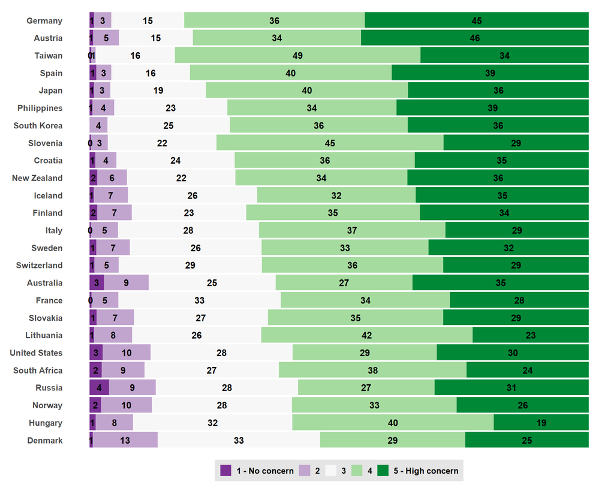

[^1]: https://access.gesis.org/dbk/77274

## The research design

Our question: **Are people in countries that experienced unusual warming more concerned about climate change?**

Why *anomalies* instead of absolute temperatures? A hot country isn’t automatically more concerned — but a country that is *unusually* hot compared to its own history might be. The anomaly captures the deviation from “normal”.

Here’s the workflow we’ll follow:

1. **Survey data** (ISSP) → climate concern per country & year
2. **EO data** (ERA5) → annual mean temperature per country & year
3. **Baseline** (1961–1990) → long-term “normal” temperature per country
4. **Anomaly** = focal year temperature − baseline
5. **Join & compare** — do anomalies track with concern?

## EO indicators

We want to investigate whether temperature anomalies in the year of the survey, compared to a long-running average, are associated with climate change concerns.

1. *Indicator*: Temperature - annual average
2. *Intensity*: Anomaly (mean deviation)
3. *Focal time period*: 1993, 2000, 2010, 2020
4. *Baseline period*: 1961-1990
5. *Spatial buffer*: Country

## ERA5 data

The ERA5-Land Reanalysis from the Copernicus Climate Change Service is a suitable data product for this temperature indicator. It records observations on air temperature at 2 meters above the surface from 1950 onwards, has a spatial resolution of 0.1x0.1 degrees, and has global spatial coverage. We can apply our conceptualization exactly to these data.

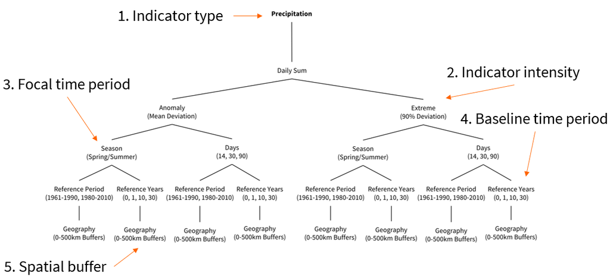

## Data access and preparation

To access the data, we need an ECMWF account. Utilizing the `ecmwfr` package, we can access the data directly in `R`. Given that we want to aggregate the data at the country level, we first load country vector data and download the data according to the spatial extent of the countries included in the survey. The ISSP has a diverse membership from North and South America, Europe, Africa, and Asia. Thus, we can work with a global spatial extent when downloading the EO indicator.

We also need some packages to load and prepare the world map and process the raster files (`rnaturalearth`, `sf`, `terra`, and `tidyverse`). We also need the `keyring` package to safely store our ECMWF-API key.

```r
required_packages <-
  c("keyring", "rnaturalearth", "sf", "tidyverse", "terra", "devtools")

new_packages <-
  required_packages[!(required_packages %in% installed.packages()[,"Package"])]

if(length(new_packages)) install.packages(new_packages)

lapply(required_packages, library, character.only = TRUE)
```

## Country level shapefile

We load the vector data containing country-level polygons and subset it to the most relevant variables.

```r
world <-
  rnaturalearth::ne_countries(
    scale = "medium",
    returnclass = "sf"
  ) |>
  dplyr::select(
    admin,
    iso_a3,
    geometry
  )

plot(sf::st_geometry(world))
```

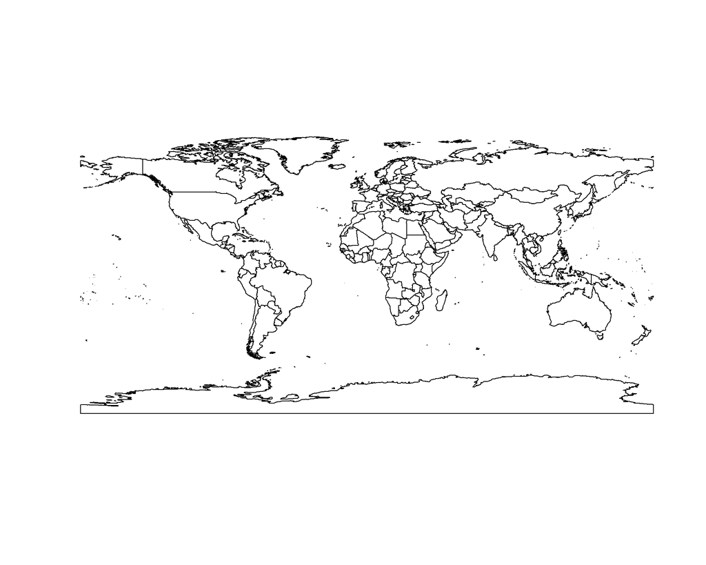

## Accessing the Copernicus API

A final step before we can access the data from the Copernicus API is to store our API key. The function automatically retrieves the key by setting it to `"wf_api_key"`.

```r
# Store as environment variable
Sys.setenv(WF_API_KEY = "MY-API-KEY")

api_key <- Sys.getenv("WF_API_KEY")

keyring::key_set_with_value(service = "wf_api_key", password = api_key)
```

Now we can access the data. We loop the download over the four years of the survey program (1993, 2000, 2010, 2020) to create four separate files.

**📦 Data already included**

The ERA5 files are pre-downloaded in `./data/era5/`. The following slides show how we obtained them so you understand the workflow — **you don’t need to run this code yourself**.

## Downloading the data

```r
# API access looped over four years
for (yr in c("1993", "2000", "2010", "2020")) {

  # Create file names which include year
  file_name <- paste0("era5_temperature", yr, ".grib")

  # Specify API request
  request <-
    list(
      data_format = "grib",
      variable = "2m_temperature",
      product_type = "monthly_averaged_reanalysis",
      time = "00:00",
      year = yr,
      month =
        c(
          "01", "02", "03", "04", "05", "06", "07", "08", "09", "10", "11", "12"
        ),
      area = c(90, -180, -90, 180),
      dataset_short_name = "reanalysis-era5-land-monthly-means",
      target = file_name
    )

  # Download data from C3S
  file_path <-
    ecmwfr::wf_request(
      request = request,
      transfer = TRUE,
      path = "./data/era5",
      verbose = FALSE
    )
}
```

## Importing the data

Importing the data into `R` should feel natural to us right now. We simply use `terra::rast()` for this endeavour.

```r
temp_1993 <- terra::rast("./data/era5/era5_temperature1993.grib")
temp_2000 <- terra::rast("./data/era5/era5_temperature2000.grib")
temp_2010 <- terra::rast("./data/era5/era5_temperature2010.grib")
temp_2020 <- terra::rast("./data/era5/era5_temperature2020.grib")
```

## Inspecting the data

Let’s inspect the datacube for 2020 and plot the first layer of the 2020 datacube (January 2020). The file’s attributes tell us information on the dimensions (number of rows, columns, and layers), the resolution, spatial extent, the coordinate reference system, units, and time points.

```r
temp_2020
```

```
class       : SpatRaster
size        : 1801, 3600, 12  (nrow, ncol, nlyr)
resolution  : 0.1, 0.1  (x, y)
extent      : -180.05, 179.95, -90.05, 90.05  (xmin, xmax, ymin, ymax)
coord. ref. : lon/lat Coordinate System imported from GRIB file
source      : era5_temperature2020.grib
names       : SFC (~e [C], SFC (~e [C], SFC (~e [C], SFC (~e [C], SFC (~e [C], SFC (~e [C], ...
unit        : C
time        : 2020-01-01 01:00:00 to 2020-12-01 01:00:00 UTC (12 steps)
```

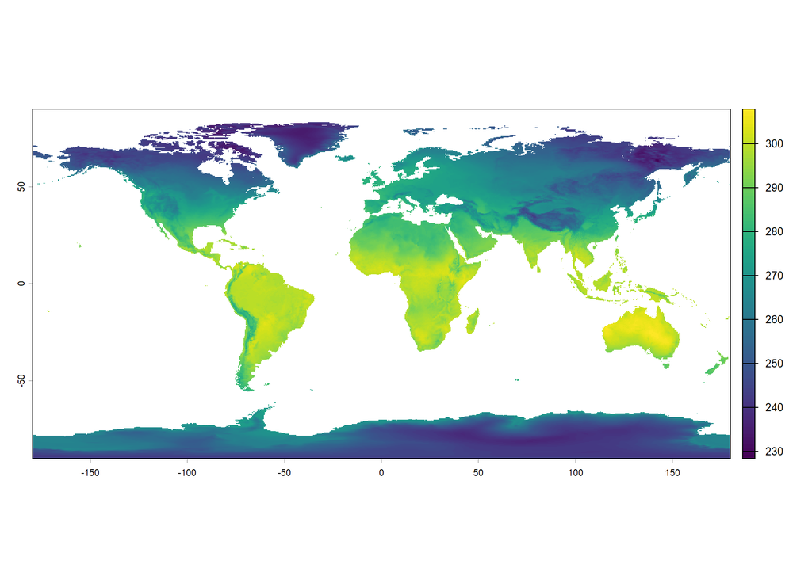

```r
plot(temp_2020[[1]])
```

## Aggregating to the country level

Now, we can aggregate the monthly values by year and country. If necessary, we will check that our country polygons and the raster files have the same CRS and align.

```r
for (yr in c("1993", "2000", "2010", "2020")) {
  temp_data <- get(paste0("temp_", yr))

  # Check CRS of both datasets and adjust if necessary
  if(!identical(terra::crs(world), terra::crs(temp_data))) {
    world <-
      world |>
      sf::st_transform(sf::st_crs(temp_data))
  }

  # Collapse the month layers into one layer by averaging across months
  annual_values <- terra::app(temp_data, fun = mean, na.rm = TRUE, cores = 4)

  # Aggregate by country
  country_values <-
    terra::extract(
      annual_values,
      world,
      fun = mean,
      na.rm = TRUE
    )

  # Add values to shapefile
  world[paste0("temp_", yr)] <- country_values[, 2]
}
```

```
|---------|---------|---------|---------|
=========================================


|---------|---------|---------|---------|
=========================================


|---------|---------|---------|---------|
=========================================


|---------|---------|---------|---------|
=========================================
```

## The result

We now have our country polygon vector file with yearly mean temperatures for each survey year.

```r
head(world, 2)
```

```
Simple feature collection with 2 features and 6 fields
Geometry type: MULTIPOLYGON
Dimension:     XY
Bounding box:  xmin: 21.97891 ymin: -22.40205 xmax: 33.66152 ymax: -8.193652
Geodetic CRS:  Coordinate System imported from GRIB file
     admin iso_a3                       geometry temp_1993 temp_2000 temp_2010
1 Zimbabwe    ZWE MULTIPOLYGON (((31.28789 -2...  294.3789  293.3119  294.4570
2   Zambia    ZMB MULTIPOLYGON (((30.39609 -1...  294.8202  294.7319  295.1083
  temp_2020
1  294.6193
2  295.2352
```

```r
plot(world["temp_2020"])
```

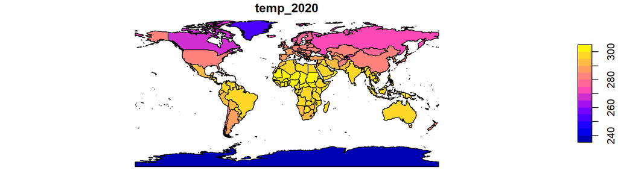

## Gathering the baseline data

Now that we have the focal values for all four survey years, we redo the process for the baseline period (1961-1990). (Again, this data is already pre-downloaded — the code is shown for reference.)

```r
# Specify API request
request <-
  list(
    data_format = "grib",
    variable = "2m_temperature",
    product_type = "monthly_averaged_reanalysis",
    time = "00:00",
    year = as.character(1961:1990),
    month =
      c("01", "02", "03", "04", "05", "06", "07", "08", "09", "10", "11", "12"),
    area = c(90, -180, -90, 180),
    dataset_short_name = "reanalysis-era5-land-monthly-means",
    target = "era5_temperature1961-1990.grib"
  )

# Download data from C3S
file_path <-
  ecmwfr::wf_request(
    request = request,
    transfer = TRUE,
    path = "./data/era5",
    verbose = FALSE
  )
```

## Importing the data

Again, we use `terra::rast()` to import the data.

```r
temp_base <-
  terra::rast("./data/era5/era5_temperature1961-1990.grib")
```

## Aggregating to the country level

We also aggregate these data at the country level and add them to our country polygon vector data.

```r
# Check CRS of both datasets and adjust if necessary
if(!identical(terra::crs(world), terra::crs(temp_base))) {
  world <-
    world |>
    sf::st_transform(crs = sf::st_crs(temp_base))
}

# Collapse all into one layer by averaging across months and years
annual_values <- terra::app(temp_base, fun = mean, na.rm = TRUE, cores = 4)

# Aggregate by country
country_values <-
  terra::extract(
    annual_values,
    world,
    fun = mean,
    na.rm = TRUE
  )

# Add values to vector data
world$temp_base <- country_values[, 2]
```

## The result

```r
head(world)
```

```
Simple feature collection with 6 features and 7 fields
Geometry type: MULTIPOLYGON
Dimension:     XY
Bounding box:  xmin: -73.36621 ymin: -22.40205 xmax: 109.4449 ymax: 41.9062
Geodetic CRS:  Coordinate System imported from GRIB file
      admin iso_a3                       geometry temp_1993 temp_2000 temp_2010
1  Zimbabwe    ZWE MULTIPOLYGON (((31.28789 -2...  294.3789  293.3119  294.4570
2    Zambia    ZMB MULTIPOLYGON (((30.39609 -1...  294.8202  294.7319  295.1083
3     Yemen    YEM MULTIPOLYGON (((53.08564 16...  297.5421  297.9850  298.3186
4   Vietnam    VNM MULTIPOLYGON (((104.064 10....  295.9980  295.8958  296.7712
5 Venezuela    VEN MULTIPOLYGON (((-60.82119 9...  297.7739  297.5062  298.3977
6   Vatican    VAT MULTIPOLYGON (((12.43916 41...  288.3732  289.0528  288.5110
  temp_2020 temp_base
1  294.6193  294.1319
2  295.2352  294.8179
3  298.2873  297.3228
4  296.7613  295.6958
5  298.7989  297.8074
6  289.6033  288.1982
```

## Calculating deviations

Now that we have the focal and baseline values, we calculate single deviations.

```r
world <-
  world |>
  dplyr::mutate(
    diff_1993 = temp_1993 - temp_base,
    diff_2000 = temp_2000 - temp_base,
    diff_2010 = temp_2010 - temp_base,
    diff_2020 = temp_2020 - temp_base
  )

# Plot 2020 deviation from baseline
ggplot(data = world) +
  geom_sf(aes(fill = diff_2020)) +
  scale_fill_viridis_c() +
  theme_minimal() +
  labs(
    title =
      "Deviation of 2020 temperature from baseline",
    subtitle = "Averaged across countries",
    fill = "Temperature (K)"
  )
```

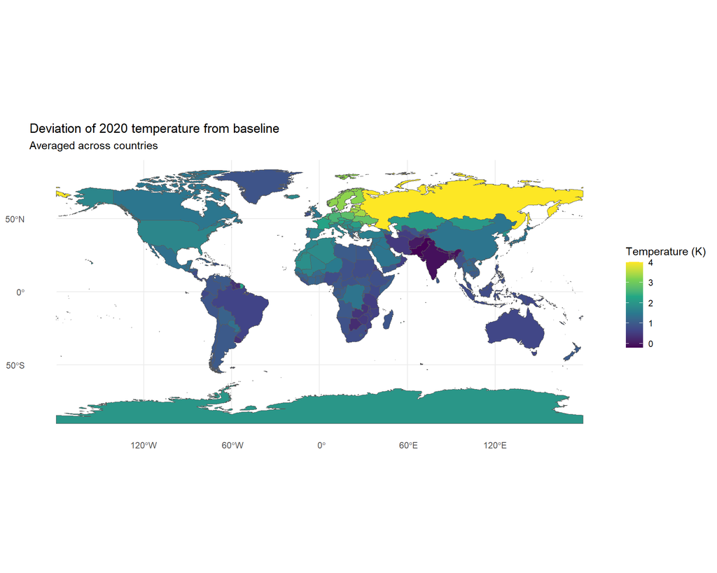

## Restructuring the temperature data

First, we reshape the temperature anomalies into long format — one row per country and year, keeping the raw values in Kelvin. No standardization needed.

```r
world_restructured <-
  world |>
  sf::st_drop_geometry() |>
  dplyr::select(
    country = admin,
    dplyr::contains("diff_")
  ) |>
  tidyr::pivot_longer(
    cols = dplyr::contains("diff_"),
    values_to = "temp_diff",
    names_to = "diff"
  ) |>
  dplyr::mutate(
    year = as.numeric(stringr::str_extract(diff, "\\d{4}"))
  )

world_restructured
```

```
# A tibble: 968 × 4
   country  diff      temp_diff  year
   <chr>    <chr>         <dbl> <dbl>
 1 Zimbabwe diff_1993   0.247    1993
 2 Zimbabwe diff_2000  -0.820    2000
 3 Zimbabwe diff_2010   0.325    2010
 4 Zimbabwe diff_2020   0.487    2020
 5 Zambia   diff_1993   0.00230  1993
 6 Zambia   diff_2000  -0.0860   2000
 7 Zambia   diff_2010   0.290    2010
 8 Zambia   diff_2020   0.417    2020
 9 Yemen    diff_1993   0.219    1993
10 Yemen    diff_2000   0.662    2000
# ℹ 958 more rows
```

## Linking at the individual level

Remember `terra::extract()` from Session 3? We used it to link raster values to points and polygons. That’s exactly what we did earlier — aggregating gridded temperatures to country polygons. Now we join the anomalies directly to **every individual respondent** via country name and year. This is the core pattern: **spatial aggregation** (raster → polygons) followed by a **tabular join** (via `dplyr::left_join()`).

```r
issp_linked <-
  issp |>
  dplyr::mutate(
    country = ifelse(
      country == "USA",
      "United States of America",
      country
    )
  ) |>
  dplyr::left_join(
    world_restructured,
    by = c("country", "year")
  )

issp_linked
```

```
      year   country concern      diff   temp_diff
1     1993 Australia       4 diff_1993 -0.12104670
2     1993 Australia       4 diff_1993 -0.12104670
3     1993 Australia       5 diff_1993 -0.12104670
4     1993 Australia       3 diff_1993 -0.12104670
5     1993 Australia       3 diff_1993 -0.12104670
6     1993 Australia       3 diff_1993 -0.12104670
7     1993 Australia       3 diff_1993 -0.12104670
8     1993 Australia       4 diff_1993 -0.12104670
9     1993 Australia       3 diff_1993 -0.12104670
10    1993 Australia       3 diff_1993 -0.12104670
11    1993 Australia       4 diff_1993 -0.12104670
12    1993 Australia       3 diff_1993 -0.12104670
13    1993 Australia       5 diff_1993 -0.12104670
14    1993 Australia       4 diff_1993 -0.12104670
```

[output cut: 19986 more lines]

## Individual-level view: The full picture

We group countries by the size of their temperature anomaly — **cooler than baseline** (≤ 0 K), **slightly warmer** (0–1 K), or **clearly warmer** (> 1 K) — and show how individual concern responses (1–5) are distributed within each group. This is the raw data before any aggregation.

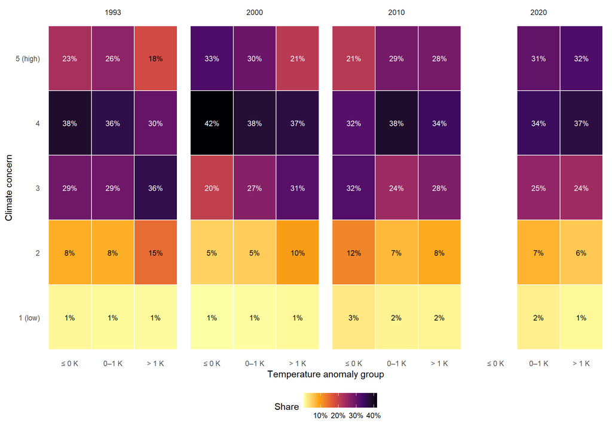

## Now let’s aggregate — what changes?

We deliberately move from individuals to country means — using the **same anomaly groups** as above. Compare the full concern distributions in the heatmap with these boxplots: the enormous individual variation collapses into a narrow band of country means.

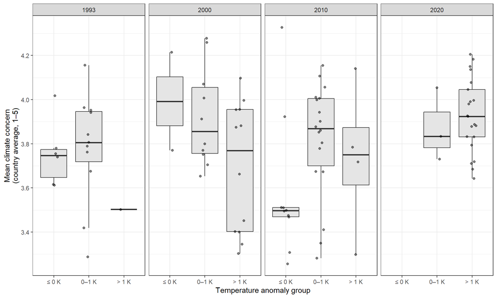

## Country trajectories: Who moves where?

Each line is one country traced through the survey years it participated in. The x-axis is the temperature anomaly, the y-axis is mean concern. Most countries move **rightward** (growing anomalies), but their concern trajectories diverge.

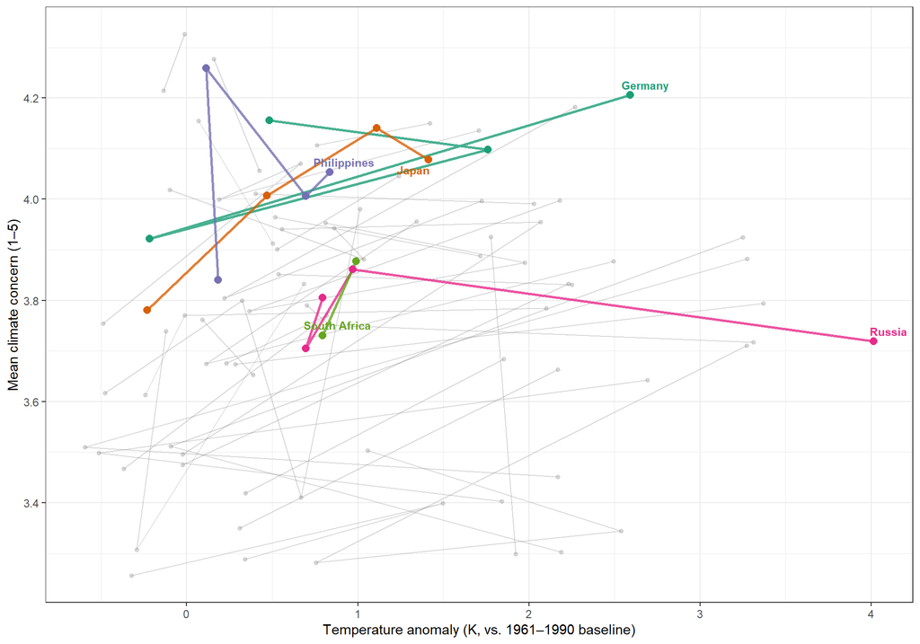

## What do we see? (1/2)

**Individual-level heatmap**

## What do we see? (2/2)

**Country trajectories**

- Almost all countries move rightward: anomalies grow from 1993 to 2020
- But concern trajectories are idiosyncratic — some countries grow more concerned, others less
- This suggests that country-specific factors (media, politics, economic context) matter more than temperature alone

**Limitations**

- Only 4 time points — too few for robust trend analysis
- No causal claim possible: many confounding factors
- Finer spatial resolution (e.g., NUTS-2 regions) would strengthen the analysis

$\rightarrow$ But as a **workflow demonstration**, this shows how survey and EO data can be integrated end-to-end using the tools we’ve learned in this course.

## Exercise 7_1: Data Integration

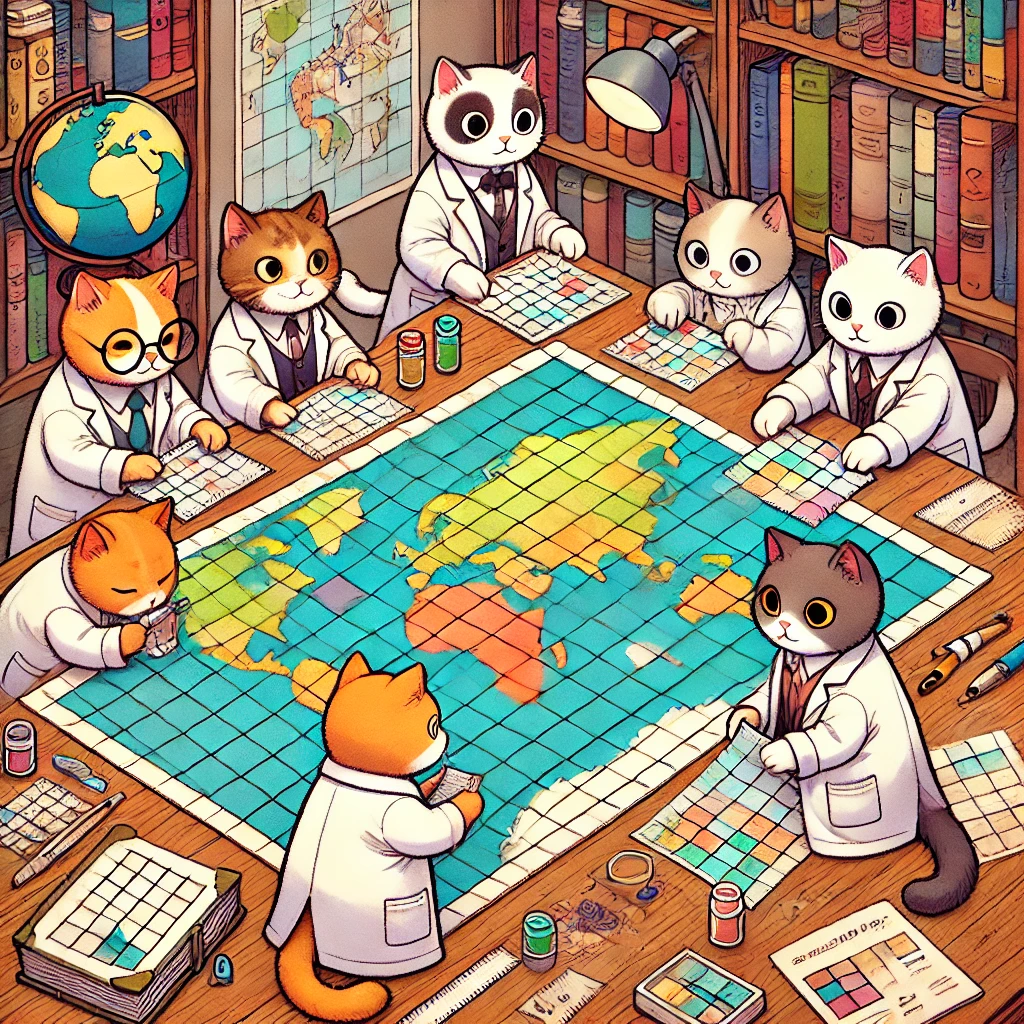

## Appendix: Plot code

The following code produces the three analysis plots shown earlier. It is provided as a reference — you don’t need to type it during the session.

## Individual-level heatmap

```r
issp_linked |>
  dplyr::filter(!is.na(concern), !is.na(temp_diff)) |>
  dplyr::mutate(
    warming = cut(
      temp_diff,
      breaks = c(-Inf, 0, 1, Inf),
      labels = c("≤ 0 K", "0–1 K", "> 1 K")
    ),
    concern = factor(concern, labels = c("1 (low)", "2", "3", "4", "5 (high)"))
  ) |>
  dplyr::count(year, warming, concern) |>
  dplyr::group_by(year, warming) |>
  dplyr::mutate(prop = n / sum(n)) |>
  ggplot(aes(x = warming, y = concern, fill = prop)) +
  geom_tile(color = "white", linewidth = .5) +
  geom_text(aes(label = scales::percent(prop, accuracy = 1),
                color = prop > .20),
            size = 3, show.legend = FALSE) +
  scale_color_manual(values = c("TRUE" = "white", "FALSE" = "black")) +
  facet_wrap(~year, nrow = 1) +
  scale_fill_viridis_c(labels = scales::percent, option = "inferno", direction = -1) +
  labs(x = "Temperature anomaly group", y = "Climate concern", fill = "Share") +
  theme_minimal() +
  theme(legend.position = "bottom", panel.grid = element_blank())
```

## Aggregated boxplot

```r
issp_country <-
  issp_linked |>
  dplyr::filter(!is.na(concern), !is.na(temp_diff)) |>
  dplyr::mutate(
    warming = cut(
      temp_diff,
      breaks = c(-Inf, 0, 1, Inf),
      labels = c("≤ 0 K", "0–1 K", "> 1 K")
    )
  ) |>
  dplyr::group_by(country, year, warming, temp_diff) |>
  dplyr::summarize(concern = mean(concern, na.rm = TRUE), .groups = "drop")

ggplot(issp_country, aes(x = warming, y = concern)) +
  geom_boxplot(outlier.shape = NA, fill = "grey90") +
  geom_jitter(alpha = .5, width = .15, size = 1.5) +
  facet_wrap(~year, nrow = 1) +
  labs(x = "Temperature anomaly group",
       y = "Mean climate concern\n(country average, 1–5)") +
  theme_bw()
```

## Country trajectories

```r
highlight_countries <- c(
  "Germany", "Russia", "Japan",
  "United States of America", "Philippines", "South Africa"
)

country_labels <- c(
  "Germany" = "Germany", "Russia" = "Russia", "Japan" = "Japan",
  "United States of America" = "USA", "Philippines" = "Philippines",
  "South Africa" = "South Africa"
)

plot_data <- issp_country |>
  dplyr::group_by(country) |>
  dplyr::filter(dplyr::n() > 1) |>
  dplyr::ungroup() |>
  dplyr::mutate(highlight = country %in% highlight_countries)

hl_data <- plot_data |>
  dplyr::filter(highlight) |>
  dplyr::mutate(
    short = country_labels[country],
    label = ifelse(year == max(year), short, NA_character_)
  )

bg_data <- plot_data |> dplyr::filter(!highlight)

ggplot(mapping = aes(x = temp_diff, y = concern)) +
  geom_path(data = bg_data, aes(group = country),
            alpha = .3, linewidth = .4, color = "grey50") +
  geom_point(data = bg_data, aes(group = country),
             alpha = .3, size = 1.2, color = "grey50") +
  geom_path(data = hl_data, aes(group = country, color = short),
            linewidth = 1, alpha = .8) +
  geom_point(data = hl_data, aes(color = short), size = 2.5) +
  ggrepel::geom_text_repel(
    data = hl_data, aes(label = label, color = short),
    size = 3, fontface = "bold", max.overlaps = 20, seed = 42,
    show.legend = FALSE
  ) +
  scale_color_brewer(palette = "Dark2", guide = "none") +
  labs(x = "Temperature anomaly (K, vs. 1961–1990 baseline)",
       y = "Mean climate concern (1–5)") +
  theme_bw()
```